# Project: Investigate a Dataset - IMDb Movies Dataset

## Exploratory Data Analysis

### Research Question 1: Which genre maximum directors are adapting?

```python
# Created gen dataframe to separate genres.
gen = df.set_index(['popularity', 'budget', 'revenue', 'original_title', 'cast', 'director', 'runtime', 'release_date', 'vote_count', 'vote_average', 'release_year', 'budget_adj', 'revenue_adj']).apply(lambda x: x.str.split('|').explode())
gen
```

| popularity | budget | revenue | original_title | cast | director | runtime | release_date | vote_count | vote_average | release_year | budget_adj | revenue_adj | genres |
| --- | --- | --- | --- | --- | --- | --- | --- | --- | --- | --- | --- | --- | --- |
| 32.985763 | 150000000 | 1513528810 | Jurassic World | Chris Pratt\|Bryce Dallas Howard\|Irrfan Khan\|Vincent D'Onofrio\|Nick Robinson | Colin Trevorrow | 124 | 2015-06-09 | 5562 | 6.5 | 2015 | 137999939 | 1392445892 | Action |
|  |  |  |  |  |  |  |  |  |  |  |  | 1392445892 | Adventure |
|  |  |  |  |  |  |  |  |  |  |  |  | 1392445892 | Science Fiction |
|  |  |  |  |  |  |  |  |  |  |  |  | 1392445892 | Thriller |
| 28.419936 | 150000000 | 378436354 | Mad Max: Fury Road | Tom Hardy\|Charlize Theron\|Hugh Keays-Byrne\|Nicholas Hoult\|Josh Helman | George Miller | 120 | 2015-05-13 | 6185 | 7.1 | 2015 | 137999939 | 348161292 | Action |
| ... | ... | ... | ... | ... | ... | ... | ... | ... | ... | ... | ... | ... | ... |
| 0.299911 | 12000000 | 20000000 | The Sand Pebbles | Steve McQueen\|Richard Attenborough\|Richard Crenna\|Candice Bergen\|Emmanuelle Arsan | Robert Wise | 182 | 2066-12-20 | 28 | 7.0 | 1966 | 80616176 | 134360293 | Drama |
|  |  |  |  |  |  |  |  |  |  |  |  | 134360293 | War |
|  |  |  |  |  |  |  |  |  |  |  |  | 134360293 | Romance |
| 0.207257 | 5115000 | 12000000 | Fantastic Voyage | Stephen Boyd\|Raquel Welch\|Edmond O'Brien\|Donald Pleasence\|Arthur O'Connell | Richard Fleischer | 100 | 2066-08-24 | 42 | 6.7 | 1966 | 34362645 | 80616176 | Adventure |
|  |  |  |  |  |  |  |  |  |  |  |  | 80616176 | Science Fiction |

10290 rows × 1 columns

```python
# Creating a function and calculating occurence counts for each genre.
def genres_function(x):
    z = gen.genres.value_counts()
    return z
```

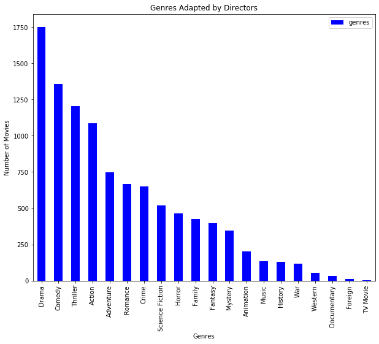

```python
#Plotting Bar Chart.
gen.apply(genres_function).plot(kind='bar', figsize=(10,8), color='blue')
plt.title('Genres Adapted by Directors')
plt.xlabel('Genres')
plt.ylabel('Number of Movies');
```

### Research Question 2: In which year maximum movies were released?

```python
# Calculating top 20 years with maximum movie releases.
# I have decided to take only top 20 because it was difficult to do analysis with all the data as the data is too huge.
year = df['release_year'].value_counts().head(20)
year
```

```
2011    199
2013    180
2010    178
2009    174
2006    169
2008    166
2014    165
2007    164
2005    163
2015    160
2012    157
2004    147
2002    126
2003    121
2001    121
1999    116
2000    106
1998     92
1997     90
1996     86
Name: release_year, dtype: int64
```

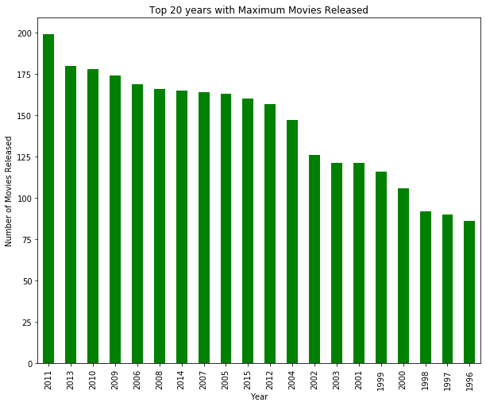

```python
#Plotting Bar Chart.
year.plot(kind = 'bar', figsize=(10,8), color='green')
plt.title('Top 20 years with Maximum Movies Released')
plt.xlabel('Year')
plt.ylabel('Number of Movies Released');
```

```python
#Calculating the average revenue earned by a movie and grouping it through original title.
#I have implemented sample function here because data is too large and I wasn't able to accomodae all the data in one graph.
#So, everytime we run this cell new samples are selected randomly from the dataset. Giving us insights for different movies.
rev = df.groupby('original_title').revenue.mean().sample(20)
rev
```

```
original_title
The Imitation Game                                   233555708.0
The Whole Ten Yards                                   26155781.0
Adventureland                                         17164377.0
Why Did I Get Married?                                55184721.0
Buried                                                19152480.0
Extreme Measures                                      17380126.0
The Boat That Rocked                                  36348784.0
The Bourne Supremacy                                 288500217.0
The Sum of All Fears                                       193.0
Step Up 2: The Streets                               150816700.0
The Lord of the Rings: The Fellowship of the Ring    871368364.0
Passengers                                             2000000.0
The Silence of the Lambs                             272742922.0
Despicable Me 2                                      970761885.0
The Ballad of Jack and Rose                             712294.0
Escape Plan                                          122915111.0
Rango                                                245724603.0
Halloween: H20                                        55041738.0
Joe Dirt                                              30987695.0
Domestic Disturbance                                  54249294.0
Name: revenue, dtype: float64
```

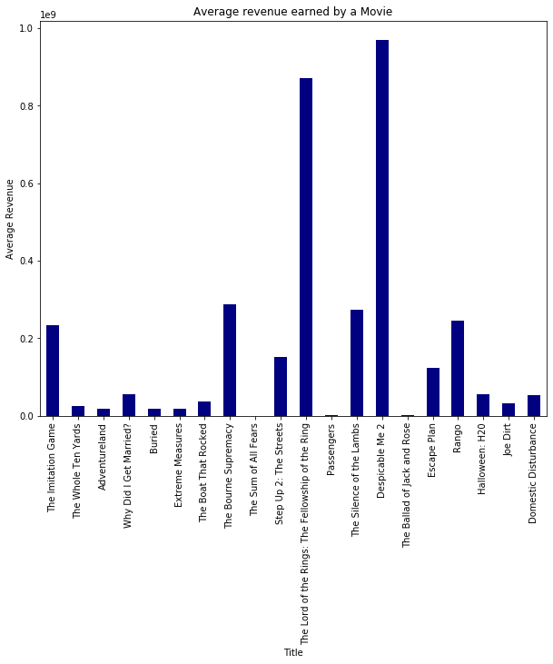

```python
#Plotting Bar Chart.
rev.plot(kind = 'bar', figsize=(10,8), color='navy');
plt.title('Average revenue earned by a Movie')
plt.xlabel('Title')
plt.ylabel('Average Revenue');
```

## Conclusions

### Limitations

- There were many columns which had missing values in 1000's and they were removed beacuse they were categorical and I was not able to compute mean for those columns. I think they were not that necessary for analysis as they all were unique categorical values.
- The results are limited to this sample dataset only as this is a really specific dataset for movies and the analysis are centric to the data columns of this dataset.
- The analysis for revenue and budget for movies would be really strong and could have given results for movies profit and loss. The analysis of average revenue generated by movies in a year is also possible.